# Growth, age, and income

Use `sample_growth_tb` to compare distributions of log growth over 2014–2015 by beginning-of-period income and age classes. Create density plots by income class and age class, and plot mean excess functions by income class for a sample restricted by income and age.

## 1 Setting sample conditions

```r
library(tidyverse)
library(pins)
library(scattermore)
# Specify relative paths for the board, figure output directory, and plotting theme.
board <- board_folder("../income_board_replicate")
graph_dir <- "graph"
dir.create(graph_dir, recursive = TRUE, showWarnings = FALSE)
source("theme_ipsum_like.R")
theme_set(theme_ipsum())
```

**Sample selection and class construction**

Extract the six periods starting in 2014 from the growth data and calculate beginning-of-period age as 2014 minus the birth year in the first four characters of `birth_date`. Classify beginning-of-period income and age as follows, and extract 2014–2015 (`g_15_14`).

- Income: classify positive beginning-of-period income `pre_income` in yen using boundaries $10^5,10^{5.5},\ldots,10^9$  
  Each class excludes its lower bound and includes its upper bound. Assign observations above $10^9$ to `size_9_over` and missing or nonpositive values to `size_other`.
- Age: classify beginning-of-period ages into 0–19, 20–24, 25–29, subsequent five-year intervals through 75–79, and 80 or older  
  Assign missing or negative values to `age_other`.

Store the 2014–2015 data in `growth_2014_tb`. For the density-plot data `density_tb`, exclude zero growth and growth with an absolute value of at least 3.5.

```r
sample_growth_tb <- board |> pin_read("sample_growth_tb")

size_depend_tb <- sample_growth_tb |>
  filter(str_sub(year, -2) == "14") |>
  mutate(
    age = as.numeric(str_c("20", str_sub(year, -2))) - as.numeric(str_sub(birth_date, 1, 4)),
    size_class = ifelse(
      is.na(pre_income), "size_other",
      cut(
        pre_income,
        breaks = c(-Inf, 0, 10^{seq(5, 9.0, by = .5)}, Inf),
        labels = c("size_other", "size_5_below", str_c("size_", seq(5.5, 9.0, by = .5)), "size_9_over"),
        right = T, include.lowest = T) |> as.character()),
    age_class = ifelse(
      is.na(age) | age < 0, "age_other",
      cut(
        age,
        breaks = c(0, seq(20, 80, by = 5), Inf),
        labels = c("age_20_below", str_c("age_", seq(20, 75, by = 5)), "age_80_plus"),
        right = FALSE, include.lowest = TRUE) |> as.character())) |>
  filter(!is.na(growth), !is.na(size_class), !is.na(age_class))

growth_2014_tb <- size_depend_tb |>
  filter(year == "g_15_14")

density_tb <- growth_2014_tb |>
  filter(growth != 0, abs(growth) < 3.5)
```

```r
age_class_labels <- c(
  "age_20_below" = "0–19",
  "age_20"       = "20–24",
  "age_25"       = "25–29",
  "age_30"       = "30–34",
  "age_35"       = "35–39",
  "age_40"       = "40–44",
  "age_45"       = "45–49",
  "age_50"       = "50–54",
  "age_55"       = "55–59",
  "age_60"       = "60–64",
  "age_65"       = "65–69",
  "age_70"       = "70–74",
  "age_75"       = "75–79",
  "age_80_plus"  = "80+",
  "age_other"    = "Other"
)

size_class_labels <- c(
  size_other   = '"Other/NA"',
  size_5_below = 'paste("(", 0,        ", ", 10^5,      "]")',
  size_5.5     = 'paste("(", 10^5,     ", ", 10^{5.5},  "]")',
  size_6       = 'paste("(", 10^{5.5}, ", ", 10^6,      "]")',
  size_6.5     = 'paste("(", 10^6,     ", ", 10^{6.5},  "]")',
  size_7       = 'paste("(", 10^{6.5}, ", ", 10^7,      "]")',
  size_7.5     = 'paste("(", 10^7,     ", ", 10^{7.5},  "]")',
  size_8       = 'paste("(", 10^{7.5}, ", ", 10^8,      "]")',
  size_8.5     = 'paste("(", 10^8,     ", ", 10^{8.5},  "]")',
  size_9       = 'paste("(", 10^{8.5}, ", ", 10^9,      "]")',
  size_9_over  = 'paste("(", 10^9,     ", ", infinity,  "  ]")'
)
```

## 2 Growth densities by income and age class

**Densities by income class**

Use `density_tb` to compare growth densities by beginning-of-period income class. For this figure, retain `size_other` and `age_other` and impose no additional income floor or age restrictions. Display a horizontal range of −2 to 2 and a vertical range of $10^{-2.5}$ to $10^1$.

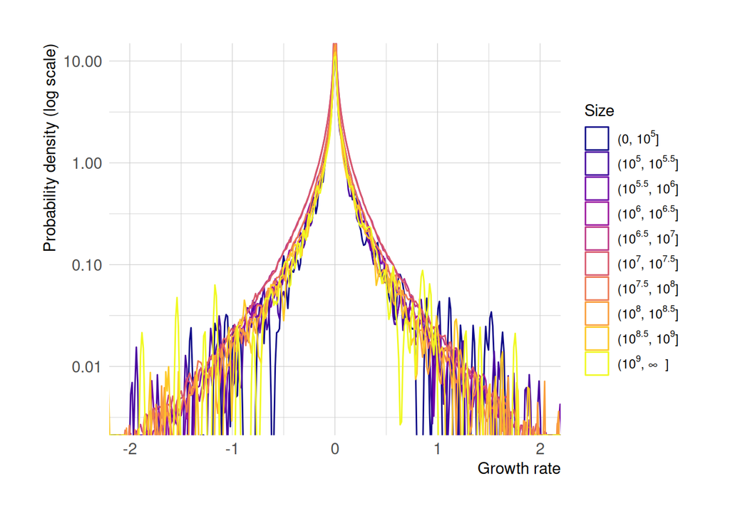

```r
density_tb |>
ggplot() +
  geom_density(aes(growth, color = size_class)) +
  scale_color_viridis_d(
    option = "C",
    breaks = names(size_class_labels),
    #labels = size_class_labels
    labels = \(x) parse(text = size_class_labels[x])
  ) +
  scale_y_log10() +
  coord_cartesian(xlim = c(-2.0, 2.0), ylim = c(10^{-2.5}, 10^1)) +
  labs(x = "Growth rate",
       y = "Probability density (log scale)",
       color = "Size")
ggsave(filename = "growth_df_size_income.png", path = graph_dir)
```

**Densities by age class**

Exclude `age_other` from the common density sample `density_tb` and compare growth densities by age class. Apply no additional income-class restrictions, and use the same scales and display ranges as in the income-class figure.

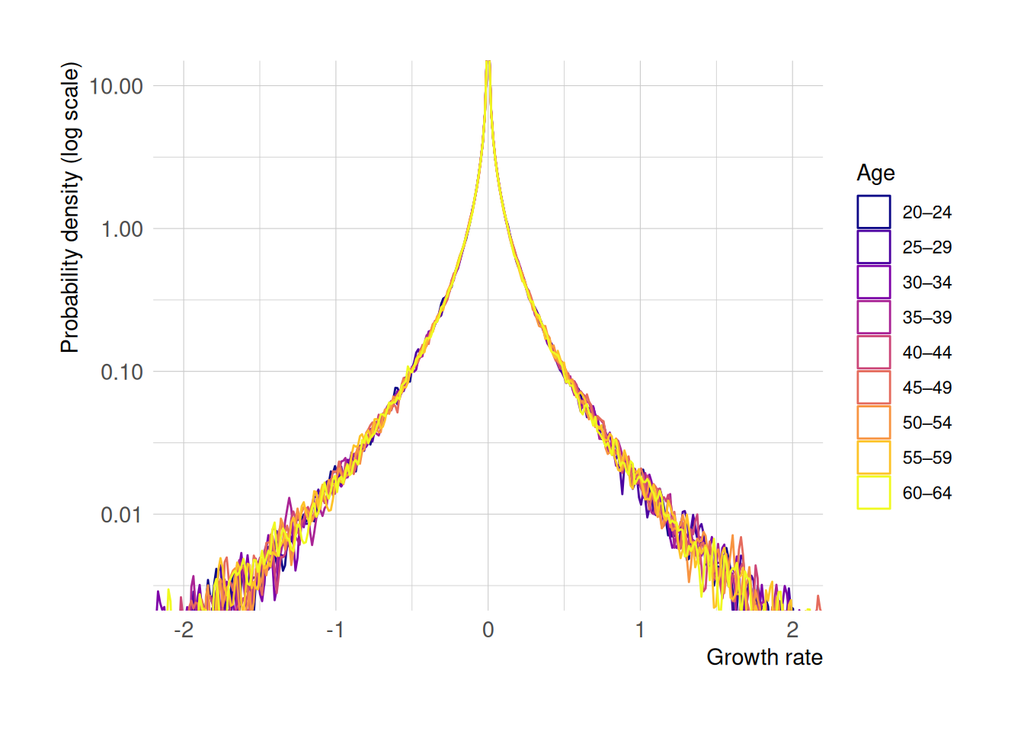

```r
density_tb |>
  filter(age_class != "age_other") |>
  mutate(age_class = factor(age_class, levels = names(age_class_labels))) |>
ggplot() +
  geom_density(aes(growth, color = age_class)) +
  scale_color_viridis_d(
    option = "C",
    labels = age_class_labels
  ) +
  scale_y_log10() +
  coord_cartesian(xlim = c(-2.0, 2.0), ylim = c(10^{-2.5}, 10^1)) +
  labs(x = "Growth rate",
       y = "Probability density (log scale)",
       color = "Age")
ggsave(filename = "growth_df_age_income.png", path = graph_dir)
```

## 3 Mean excess functions with income and age restrictions

From `growth_2014_tb`, select observations with beginning-of-period income of at least $10^{6.5}$ yen, outside `size_9_over`, and beginning-of-period age between 25 and 60, inclusive. Let $g_{(i)}$ denote growth rates in descending order within each class. Calculate the following expression.

$$m_{\mathrm{excess},i}=\frac{1}{i-1}\sum_{j=1}^{i-1}g_{(j)}-g_{(i)}, \qquad i\geq2.$$

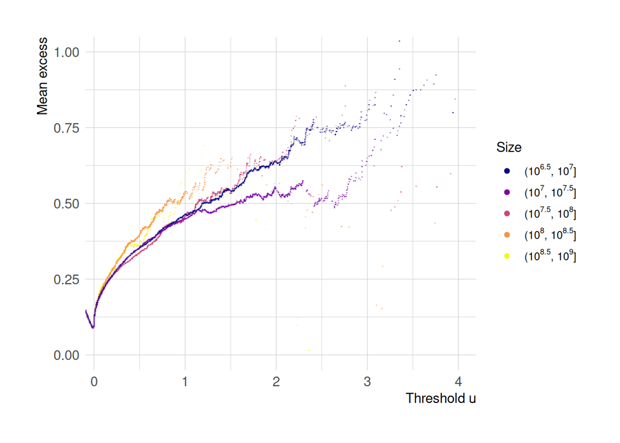

```r
growth_2014_tb |>
  filter(
    pre_income >= 10^6.5, size_class != "size_9_over",
    age >= 25, age <= 60
  ) |>
  arrange(desc(growth)) |>
  group_by(size_class) |>
  mutate(m_excess = lag(cummean(growth)) - growth) |>
ggplot(aes(growth, m_excess, color = size_class)) +
  geom_scattermore(pointsize = 1.2) +
  scale_color_viridis_d(
    option = "C",
    labels = \(x) parse(text = size_class_labels[x])
  ) +
  coord_cartesian(xlim = c(0.1, 4), ylim = c(0, 1.0)) +
  labs(
    x = "Threshold u",
    y = "Mean excess",
    color = "Size"
  )
ggsave(filename = "mean_excess_relevant_income.png", path = graph_dir)
```